# Clase 1 - Introducción a Python

```python
#Configuraciones de Python
import pandas as pd
pd.options.display.max_rows = 20
```

[figure not shown]

```python
from IPython.display import Image
Image(filename='./logo_python.png')
```

## Introducción a Python

Algunas de las características más importantes en python:

- Utiliza una sintaxis bastante limpia y legible.
- Posee una gran biblioteca estándar con paquetes para múltiples tareas, además de contar con una gran variedad de paquetes externos.
- Python soporta programación orientada a objetos con clases y herencia múltiple.
- Python gestiona automáticamente la memoria.
- Python es un lenguaje débilmente tipado o no tipado estáticamente.

## Conceptos Básicos

En Python se dice que todo es un objeto, por lo que hay que entender que es un objeto para entender python.

Los siguientes conceptos son importantes cuando empezamos a trabajar con python:

**Clase**: En la definición de un nuevo **tipo de objeto**, una **clase** define las características (**atributos**) y el comportamiento (**métodos**) que mejor describen a un objeto de la vida real o de un sistema informático. También define la manera como se crea el **objeto**.

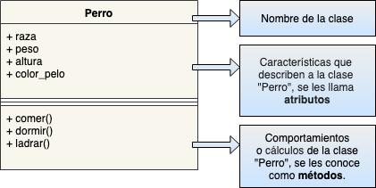

```python
from IPython.display import Image
Image(filename='./clase.png')
```

Una analogía muy sencilla es la de un plano arquitectónico para construir una casa, ya que podríamos ver a la **clase** como el plano arquitectónico y a la casa como el **objeto**.

**Objeto**: es la instancia de una **clase**, que posee comportamientos (**métodos**) y caracteristicas (**atributos**). Los objetos se puede clasificar en dos grandes tipos: **inmutables** y **mutables**.

- **inmutables**: son los objetos que no se pueden modificar y que si se quieren modificar se tienen que crear un nuevo objeto con la modificación necesaria. Los objetos inmutables más comunes en Python son los de tipo: `int`, `float`, `str`, `bool` y `tuple`.
- **mutables**: son los objetos que se pueden modificar, por lo generar el operador de asignación (`=`) no crea un nuevo objeto. Los objetos mutables más comunes en Python son los de tipo: `list`, `set` y `dict`.

## Variables y asignación de variables

En python **todo** es un objeto así que podemos ver una variable como un lugar donde se almacena una instancia de un objeto para luego utilizar este valor mediante un nombre que nosotros asignemos.

Las variables se crean usando el operador de asignación `=` de la siguiente forma:

**< Nombre de la variable >** `=` **< Valor de la variable >**

**Nota**: Es mejor usar las variables en minúsculas por estándar de python.

```python
mi_variable = "Hola Mundo de Python!"
mi_variable
```

```
'Hola Mundo de Python!'
```

```python
mi_variable = 5
mi_variable
```

```
5
```

```python
x, y = 20, 15
print(x)
print(y)
```

```
20
15
```

```python
mi_variable = x + y
mi_variable
```

```
35
```

Técnicamente una variable es una dirección de la memoria RAM que podemos gestionar, pero al ser Python un lenguaje débilmente tipado y con un "recolector de basura" no es necesario la administración de la memoria sino que basta con la manipulación de las variables. Una forma de ver la asignación en memoria de las variables es utilizando la función `id` ya que esta nos muestra la dirección en la memoria RAM del objeto que contenga la variable de forma numérica y este valor es un identificador único del objeto durante su ciclo de vida.

**Nota**: La función `print` nos es útil para imprimir el contenido de cualquier objeto que posee un método `_str_`. La vamos a usar para ver los valor de las variables y ejemplificar cómo se comporta el hilo de ejecución en python con fines didácticos.

## Tipos de datos

En python se puede encontrar una gran variedad de tipos de datos, pero es importante que se entienda que en el fondo todos estos tipos de datos son objetos, entre los más básicos se encuentran:

**Nota**: Para esta parte vamos a usar mucho la función `type` que nos regresa el tipo del objeto que le ingresemos. Al igual que con `print` estamos usando `type` con fines didácticos y no es necesario su uso.

### Booleanos

En programación es muy frecuente ver este tipo de datos para representar las operaciones lógicas, el tipo de estos datos en python es `bool`.

Este tipo de datos solo constan de dos valores posibles `True` o `False`, los cuales denotan "verdad" y "falsedad" respectivamente.

Las variables de tipo `bool` son objetos inmutables.

Más adelante veremos cómo usar estos valores de manera adecuada.

```python
mi_variable = True
type(mi_variable)
```

```
bool
```

```python
mi_variable = False
type(mi_variable)
```

```
bool
```

### Números enteros

Podemos encontrar los números enteros cuyo tipo en python se denomina `int` y son un tipo de objeto inmutable.

```python
mi_variable = 5
type(mi_variable)
```

```
int
```

### Números con puntos decimales

Los números reales poseen un tipo especial `float`, son un tipo de objeto inmutable. A estos números también se les conoce como números de punto flotante.

```python
mi_variable = 3.1415
type(mi_variable)
```

```
float
```

#### Operaciones Aritméticas

Las operaciones aritméticas en python son bastante sencillas y se basan en los siguientes operadores:

[output not shown]

**Nota**: Recordemos que podemos almacenar valores en variables y las operaciones aritméticas aplican para variables con valores numéricos.

```python
x = 7
y = 6.5
```

```python
x + y
```

```
13.5
```

```python
x - y
```

```
0.5
```

```python
y * x
```

```
45.5
```

```python
x / y
```

```
1.0769230769230769
```

```python
x // y
```

```
1.0
```

```python
x ** 2
```

```
49
```

```python
x ^ 2
```

```
5
```

Se sigue el mismo orden que el de la aritmética convencional:

- Exponentes.
- Módulos.
- Multiplicaciones y Divisiones.
- Sumas y Restas.

```python
x + y * 10 / 4
```

```
23.25
```

```python
x + ((y * 10) / 4)
```

```
23.25
```

Pero se puede alterar este orden usando paréntesis.

```python
((x + y) * 10) / 4
```

```
33.75
```

Si quisiéramos usar algunos valores por defecto como $\pi$ o $e$ tenemos que cargar la librería `math` que vienen con python.

Para cargar una librería podemos usar:

**import** < nombre de la librería >

**import** < nombre de la librería > **as** < un alias >

```python
import math as mt

mt.pi
```

```
3.141592653589793
```

```python
mt.e
```

```
2.718281828459045
```

La librería math posee una gran variedad de constantes y funciones útiles, por ejemplo:

`inf`: Representa el infinito.

```python
mt.inf
```

```
inf
```

`nan`: Representa un valor no numérico (No a number), se usa mucho como valor nulo o una indeterminación matemática.

```python
mt.nan
```

```
nan
```

`log(número, base)`: El el logaritmo de **número** en base **base**.

```python
mt.log(3, 10)
```

```
0.47712125471966244
```

`ceil`: Redondea hacia arriba.

```python
mt.ceil(4.1)
```

```
5
```

`floor`: Redondea hacia abajo.

```python
mt.floor(5.9)
```

```
5
```

`sqrt`: Raíz cuadrada

```python
mt.sqrt(4)
```

```
2.0
```

`cos`: La función coseno.

```python
mt.cos(0)
```

```
1.0
```

`sin`: La función seno.

```python
mt.sin(0)
```

```
0.0
```

`tan`: La función tangente.

```python
mt.tan(0)
```

```
0.0
```

`factorial`: Factorial de un número.

```python
mt.factorial(4)
```

```
24
```

Pueden encontrar más detalles sobre la libreria **math** en la [documentación de python](https://docs.python.org/3.7/library/math.html).

### Strings o cadenas de caracteres

Los strings o cadenas de caracteres es un objeto que nos permite almacenar texto. El tipo de dato para un string en python es `str`.

Los strings con objetos inmutables.

En python se pueden crear cadenas de carateres con comillas dobles (`"`)

```python
mi_variable = "¡mucho gusto!"
print(mi_variable)
type(mi_variable)
```

```
¡mucho gusto!
```

```
str
```

Con comillas simples (`'`) se puede almacenar comillas dobles (`"`) dentro del string.

```python
mi_variable = 'Esta es una "prueba"'
print(mi_variable)
type(mi_variable)
```

```
Esta es una "prueba"
```

```
str
```

También se puede usar triple comillas dobles (`"""`) para guardar texto con formato.

```python
mi_variable = """Este texto tienen "comillas" y
saltos de lineas."""
print(mi_variable)
type(mi_variable)
```

```
Este texto tienen "comillas" y
saltos de lineas.
```

```
str
```

Normalmente se utilizan caracteres especiales para indicar formato, por ejemplo un salto de línea se indica con `\n` en el texto.

```python
mi_variable = 'Este texto tienen "comillas" y \nsaltos de lineas.'
print(mi_variable)
type(mi_variable)
```

```
Este texto tienen "comillas" y
saltos de lineas.
```

```
str
```

#### Operaciones sobre Strings

Python nos proporciona formas muy sencillas de manipular variables de tipo string.

```python
nombre = "Luis"
apellido = "Perez"
print(nombre)
print(apellido)
```

```
Luis
Perez
```

Los tipos de datos `str` se pueden concatenar utilizando el operador `+` para juntar dos o más strings.

```python
nombre_completo = nombre + " " + apellido
nombre_completo
```

```
'Luis Perez'
```

De los errores más frecuentes al intentar concatenar strings es utilizar un tipo de dato que no sea `str`.

```python
edad = 20
mensaje = "Feliz " + edad + "º aniversario!"
mensaje
```

```
---------------------------------------------------------------------------
TypeError                                 Traceback (most recent call last)
<ipython-input-331-7808e7981b8f> in <module>
      1 edad = 20
----> 2 mensaje = "Feliz " + edad + "º aniversario!"
      3 mensaje

TypeError: can only concatenate str (not "int") to str
```

Esto se soluciona utilizando la función `str(...)` que nos permite cambiar el tipo de una variable.

En informática se conoce como `castear` a cambiar el tipo de dato de una variable a otro tipo. En python por lo general las funciones que nos ayudan a castear variables llevan el mismo nombre que el tipo de dato (`int(...)`, `float(...)`, `str(...)`, `list(...)`, etc)

```python
edad = 20
mensaje = "Feliz " + str(edad) + "º aniversario!"
mensaje
```

```
'Feliz 20º aniversario!'
```

Otra manera de insertar valores dentro de strings es utilizando el operador `%`

```python
edad = 15
mensaje = "Feliz %iº aniversario!" % edad # Sin casteo, el tipo se indica en %i (quiere decir tiene que ir un int)
mensaje
```

```
'Feliz 15º aniversario!'
```

Un ejemplo un poco más complejo:

```python
edad = 25
cuenta = 100.5696
id_cliente = "EA183"
mensaje = "Edad: %i \nCuenta: %.2f \nID: %s" % (edad, cuenta, id_cliente)
print(mensaje)
```

```
Edad: 25
Cuenta: 100.57
ID: EA183
```

Para el operador `%` podemos utilizar varios símbolos:

| Símbolo | Descripción |
| --- | --- |
| %s | String o cualquier objeto con representación de string |
| %d | Números enteros |
| %i | Números enteros |
| %f | Números punto flotante |
| %.2f | Números punto flotante mostrando solo 2 decimales (la cantidad puede variar) |
| %x | hexadecimal |
| %X | hexadecimal |

También podemos encontrar una gran variedad de funciones que nos ayudan a manipular strings como:

**lower(...)**: Nos permite pasar un string a minúsculas.

```python
nombre = "LUIS PEREZ"
nombre.lower()
```

```
'luis perez'
```

**upper(...)**: Nos permite pasar un string a mayusculas.

```python
nombre = "luis perez"
nombre.upper()
```

```
'LUIS PEREZ'
```

**title(...)**: Nos permite pasar un string en formato título.

```python
nombre.title()
```

```
'Luis Perez'
```

**center(...)**: Nos permite centrar un string.

```python
nombre.center(50, "=")
```

```
'====================luis perez===================='
```

**rstrip(...)**: Elimina caracteres al final del string.

```python
lenguaje = '+++python+++'
lenguaje.rstrip("+")
```

```
'+++python'
```

**lstrip**: Elimina caracteres al principio del string

```python
lenguaje.lstrip("+")
```

```
'python+++'
```

**strip**: Elimina caracteres al principio y al final del string.

```python
lenguaje.strip("+")
```

```
'python'
```

**replace**: Replaza un caracter por otro en todo el string.

```python
lenguaje.replace("+","*")
```

```
'***python***'
```

#### Indexación en string

Los string son una de las estructuras que poseen índices, esto quiere decir que podemos obtener valores específicos según sus índices.

La indexación en Python se hace a través del operador `[]` y hay que tener en cuenta que los índices comienzan en `0` y no en `1`

```python
mi_variable = "HOLA MUNDO"
mi_variable
```

```
'HOLA MUNDO'
```

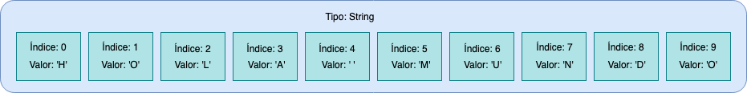

```python
from IPython.display import Image
Image(filename='./index_string.png')
```

Por ejemplo podrías obtener la primera letra del texto:

```python
mi_variable[0]
```

```
'H'
```

Podríamos obtener el tamaño del string con la función `len(...)` y con esto obtener la ultima letra:

```python
tam = len(mi_variable)
tam
```

```
10
```

```python
mi_variable[tam - 1]
```

```
'O'
```

Pero se puede hacer esto aún más sencillo, ya que Python nos permite usar índices negativos, donde `-1` es el último valor.

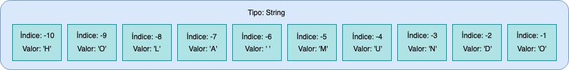

```python
from IPython.display import Image
Image(filename='./index_string2.png')
```

```python
mi_variable[-1]
```

```
'O'
```

Dentro del operador `[]` podemos usar una sintaxis bastante potente que nos permite hacer secuencias de índices para obtener valores de forma más específica, esto se hace mediante `:::`

< índice de inicio > `:` < índice final > `:` < salto >

En esta sintaxis cada paso es opcional, es decir:

- si falta < índice de inicio > se comienza desde el primer índice posible.
- si falta < índice final > se finaliza en el último índice posible.
- si falta < salto > la secuencia tendrá un salto de 1.

**Nota**: < índice de inicio >, < índice final > y < salto > tienen que ser de tipo `int`, no se permiten valores tipo `float`.

Por ejemplo si quisiera todos los valores de `mi_texto` cuyos índices sean pares lo puedo hacer de dos maneras:

**De forma incorrecta:**

```python
indices_pares = mi_variable[0] + mi_variable[2] + mi_variable[4] + mi_variable[6] + mi_variable[8]
indices_pares
```

```
'HL UD'
```

**De la forma correcta:**

```python
# 0::2 = Deste el índice 0 hasta el 9 (el ultimo índice posible) en saltos de 2 es decir:
# 0 , 2, 4, 6, 8
indices_pares = mi_variable[0::2] # También es posible poner ::2 ya que es lo mismo que 0::2
indices_pares
```

```
'HL UD'
```

```python
mi_variable[0:5]
```

```
'HOLA '
```

Si quisiéramos obtener el valor de `mi_texto` invertido podríamos usar `:::` para hacerlo de manera sencilla:

```python
mi_variable[::-1]
```

```
'ODNUM ALOH'
```

Un error muy común cuando usamos `:::` es el siguiente:

Si queremos los primeros 4 caracteres de `mi_texto`("HOLA"), es común hacer `mi_texto[:3:]` pensando en obtener los valores de los índices 0, 1, 2 y 3 (Los primeros 4 valores), pero este es un error ya que `[:3:]` se traduce como [0, 3[ es decir la secuencia resultante no incluye al < índice final > por lo que obtendremos los valores de los índices 0, 1, 2 (Los primero 3 valores).

```python
mi_variable[:3:]
```

```
'HOL'
```

Para hacerlo de manera correcta sería `[:4:]` ya que el < índice final > se excluye.

```python
mi_variable[:4:]
```

```
'HOLA'
```

## Listas

Las listas en Python son estructuras **indexadas** que nos permiten almacenar distintos tipos de datos. Estas listas son objetos mutables.

Para crear una lista se usa `[]` y aplican las mismas reglas vistas en **Indexación en string** para obtener valor de la lista. El tipo de dato de las listas es `list`.

Una lista vacía se vería de la siguiente forma:

```python
mi_variable = []
mi_variable
```

```
[]
```

```python
type(mi_variable)
```

```
list
```

Veamos un ejemplo de una lista con valores númericos:

```python
x = [10, 20, 30, 40, 50, 60, 70, 80, 90, 100]
x
```

```
[10, 20, 30, 40, 50, 60, 70, 80, 90, 100]
```

Al igual que los strings las listas poseen índices y valores, por lo que podemos acceder a dichos valores mediante el operador `[]`.

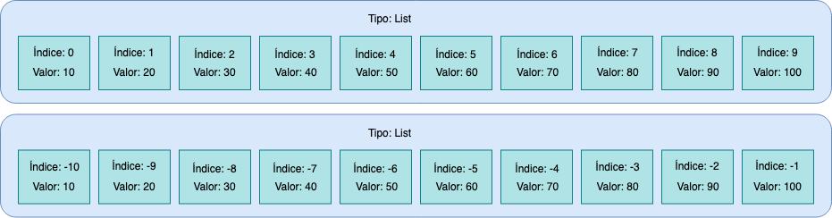

```python
from IPython.display import Image
Image(filename='./listaN.png')
```

```python
x[0]
```

```
10
```

```python
x[-1]
```

```
100
```

```python
x[1::2]
```

```
[20, 40, 60, 80, 100]
```

```python
x[:-6:-1]
```

```
[100, 90, 80, 70, 60]
```

Podemos utilizar la función `range` para crear listas numéricas:

**range**(< valor de inicio >, < valor final >, < salto >)

Al utilizar `range` el salto es opcional, es caso de no ingresarse su valor por defecto es 1.

```python
x = list(range(1, 21))
x
```

```
[1, 2, 3, 4, 5, 6, 7, 8, 9, 10, 11, 12, 13, 14, 15, 16, 17, 18, 19, 20]
```

```python
x = list(range(0, 21, 2))
x
```

```
[0, 2, 4, 6, 8, 10, 12, 14, 16, 18, 20]
```

Las listas pueden contenter cualquier tipo de dato:

```python
motocicleta = ['honda', 'yamaha', 'suzuki', 'harley']
motocicleta
```

```
['honda', 'yamaha', 'suzuki', 'harley']
```

Y dependiendo del tipo de dato podemos usar los valores del vector de una u otra forma:

```python
mensaje = "Mi motocicleta fue una " + motocicleta[0].title() + "."
mensaje
```

```
'Mi motocicleta fue una Honda.'
```

### Modificando los valores de la lista

Si buscamos modificar un solo valor por índice es tan sencillo como:

```python
motocicleta[0] = 'ducati'
motocicleta
```

```
['ducati', 'yamaha', 'suzuki', 'harley']
```

Si buscamos modificar varias entradas a la vez se tiene que hacer por una lista.

```python
motocicleta[1:3] = ['kawasaki', 'victoria']
motocicleta
```

```
['ducati', 'kawasaki', 'victoria', 'harley']
```

```python
motocicleta[1:3]
```

```
['kawasaki', 'victoria']
```

Tenemos que tener cuidado con la cantidad de valores que cambiamos ya que podríamos eliminar valores, por ejemplo:

```python
print(motocicleta)
motocicleta[1:3] = ['kawasaki']
motocicleta
```

```
['ducati', 'kawasaki', 'victoria', 'harley']
```

```
['ducati', 'kawasaki', 'harley']
```

### Agregando valores a una lista

Si queremos agregar nuevos elementos a una lista podemos usar la función `append` que nos permitirá agregar un elemento al final de la lista.

```python
letras = ['A', 'B', 'C', 'D']
letras
```

```
['A', 'B', 'C', 'D']
```

```python
letras.append('E')
letras
```

```
['A', 'B', 'C', 'D', 'E']
```

Pero cuando intentamos agregar más de un elemento vamos a tener un inconveniente ya que las listas no están obligadas a almacenar un solo tipo de dato por lo que los nuevos elementos se agregan como una lista.

```python
letras = ['A', 'B', 'C', 'D', 'E']
letras
```

```
['A', 'B', 'C', 'D', 'E']
```

```python
letras.append(['F','G'])
letras
```

```
['A', 'B', 'C', 'D', 'E', ['F', 'G']]
```

Para solventar estos problemas debemos usar la función `extend` que nos permitirá agregar múltiples elementos a una lista.

```python
letras = ['A', 'B', 'C', 'D', 'E']
letras
```

```
['A', 'B', 'C', 'D', 'E']
```

```python
letras.extend(['F','G'])
letras
```

```
['A', 'B', 'C', 'D', 'E', 'F', 'G']
```

También podemos usar el operador `+` en lugar de usar `extend` pero tenemos que asegurarnos de que ambos valores sean listas y de utilizar una asignación para mantener el resultado ya que al usar `+` estamos creando una nueva lista.

```python
letras = ['A', 'B', 'C', 'D', 'E']
letras = letras + ['F','G']
```

```python
letras
```

```
['A', 'B', 'C', 'D', 'E', 'F', 'G']
```

En caso de que ambos valores no sean listas tendremos un error:

```python
letras = ['A', 'B', 'C', 'D', 'E']
letras = letras + 'F'
```

```
---------------------------------------------------------------------------
TypeError                                 Traceback (most recent call last)
<ipython-input-380-ec38a414eaf5> in <module>
      1 letras = ['A', 'B', 'C', 'D', 'E']
----> 2 letras = letras + 'F'

TypeError: can only concatenate list (not "str") to list
```

Pero y si queremos agregar un valor en una posición específica dentro del vector el `+`, `extend` y `append` no pueden hacerlo por lo que existe la función `insert`.

```python
letras = ['A', 'B', 'D', 'E']
letras
```

```
['A', 'B', 'D', 'E']
```

```python
letras.insert(2,'C')
letras
```

```
['A', 'B', 'C', 'D', 'E']
```

### Borrando valores de una lista

En Python `del` es una palabra reservada que nos permite eliminar un objeto.

```python
mi_variable = 55
mi_variable
```

```
55
```

```python
del mi_variable
mi_variable
```

```
---------------------------------------------------------------------------
NameError                                 Traceback (most recent call last)
<ipython-input-384-d57120af0a1e> in <module>
      1 del mi_variable
----> 2 mi_variable

NameError: name 'mi_variable' is not defined
```

Y cómo podemos usar `del` para eliminar variables también podemos usarlo para eliminar elementos de una lista.

```python
letras = ['A', 'B', 'C', 'D', 'E']
letras
```

```
['A', 'B', 'C', 'D', 'E']
```

```python
del letras[0]
letras
```

```
['B', 'C', 'D', 'E']
```

También se pueden eliminar múltiples elementos de una lista

```python
letras = ['A', 'B', 'C', 'D', 'E']
letras
```

```
['A', 'B', 'C', 'D', 'E']
```

```python
del letras[0:2]
letras
```

```
['C', 'D', 'E']
```

Es muy frecuente que en lugar de eliminar un valor de una colección de datos queramos extraer ese valor y manipularlo de alguna manera. Para extraer un valor de una lista podemos usar `pop(...)`.

**Nota**: por defecto al usar `pop` extraemos el último elemento.

```python
letras = ['A', 'B', 'C', 'D', 'E']
una_letra = letras.pop()
letras
```

```
['A', 'B', 'C', 'D']
```

```python
una_letra
```

```
'E'
```

Pero también podemos usar `pop(índice)` para extraer el elemento en un índice específico.

```python
letras = ['A', 'B', 'C', 'D', 'E']
una_letra = letras.pop(0)
letras
```

```
['B', 'C', 'D', 'E']
```

```python
una_letra
```

```
'A'
```

Es posible que no sepamos el índice del elemento que queremos eliminar pero si el valor, por lo que podemos usar la función `index(valor)` para obtener el índice, por ejemplo:

```python
letras   = ['A', 'B', 'C', 'D', 'E', 'C']
indice_c = letras.index('C')
indice_c
```

```
2
```

```python
una_letra = letras.pop(indice_c)
letras
```

```
['A', 'B', 'D', 'E', 'C']
```

```python
una_letra
```

```
'C'
```

### Ordenando una lista

Para ordenar una lista en Python podemos usar la función `sort(...)`

```python
carros = ['bmw', 'audi', 'toyota', 'subaru']
carros.sort() # Ascendentemente
carros
```

```
['audi', 'bmw', 'subaru', 'toyota']
```

```python
carros.sort(reverse = True) # Descendentemente
carros
```

```
['toyota', 'subaru', 'bmw', 'audi']
```

### Longitud de una lista

Al igual que con los strings podemos usar la función `len` para obtener el tamaño de la lista.

```python
nombres = ['alice', 'david', 'carolina']
len(nombres)
```

```
3
```

### Estadísticas básicas en una lista

En Python podemos utilizar una serie de funciones que nos ayudan a conocer mejor una colección de datos o lista.

```python
mi_variable = [0.08443562673875182, 0.8564944639620772, 0.5550894802784472, 0.03085965912586397, 0.6500646911334296]
mi_variable
```

```
[0.08443562673875182,
 0.8564944639620772,
 0.5550894802784472,
 0.03085965912586397,
 0.6500646911334296]
```

```python
min(mi_variable) # Mínimo
```

```
0.03085965912586397
```

```python
max(mi_variable) # Máximo
```

```
0.8564944639620772
```

```python
sum(mi_variable) # Sumatoria
```

```
2.17694392123857
```

También podemos usar la librería `statistics` para calcular valores como la media aritmética, la mediana, etc.

```python
import statistics as st
```

```python
st.mean(mi_variable) # Media Aritmética
```

```
0.43538878424771393
```

```python
st.median(mi_variable) # Mediana
```

```
0.5550894802784472
```

```python
st.pstdev(mi_variable) # Desviación Estándar Poblacional
```

```
0.3238999620106498
```

```python
st.pvariance(mi_variable) # Varianza Poblacional
```

```
0.1049111853905004
```

```python
st.stdev(mi_variable) # Desviación Estándar en muestras
```

```
0.3621311664827062
```

```python
st.variance(mi_variable) # Varianza en muestras
```

```
0.1311389817381255
```

```python
mi_variable = ["A", "A", "B", "C", "B", "C", "C"]
st.mode(mi_variable)
```

```
'C'
```

## Tuplas

Las tuplas son muy parecidas a las listas, ya que pueden almacenar varios tipos de datos distintos. Solo que las tuplas son objetos inmutables por lo cual son listas que una vez definidas no las podemos modificar.

En Python el tipo de dato de las tuplas es de `tuple`.

Para crear un tupla usaremos los paréntesis redondos `()`.

El uso de `()` no es obligatorio, excepto cuando creamos tuplas vacías, pero es recomendable su uso para mantener un código más legible.

```python
mi_variable = ()
mi_variable
```

```
()
```

```python
type(mi_variable)
```

```
tuple
```

Podemos omitir los `()`, pero se recomienda mantenerlos.

```python
mi_variable = 'A', 'B', 'C', 'D', 'E'
mi_variable
```

```
('A', 'B', 'C', 'D', 'E')
```

```python
mi_variable = ('A', 'B', 'C', 'D', 'E')
mi_variable
```

```
('A', 'B', 'C', 'D', 'E')
```

Un error muy común al intentar crear una tupla con un solo elemento es hacer lo siguiente:

```python
x = ('A')
type(x)
```

```
str
```

La forma correcta de hacer una tupla de un solo elemento es:

```python
x = ('A',)
type(x)
```

```
tuple
```

Como lo mencionamos anteriormente una tupla no se puede modificar

```python
mi_variable = 'A', 'B', 'C', 'D', 'E'
mi_variable.append('E')
```

```
---------------------------------------------------------------------------
AttributeError                            Traceback (most recent call last)
<ipython-input-417-e0b90e8138c4> in <module>
      1 mi_variable = 'A', 'B', 'C', 'D', 'E'
----> 2 mi_variable.append('E')

AttributeError: 'tuple' object has no attribute 'append'
```

Pero al igual que las listas podemos usar `[]` para acceder a los elementos de la tupla.

```python
x = (10, 20, 30, 40, 50, 60, 70, 80, 90, 100)
x
```

```
(10, 20, 30, 40, 50, 60, 70, 80, 90, 100)
```

```python
x[0]
```

```
10
```

```python
x[-1]
```

```
100
```

```python
x[1::2]
```

```
(20, 40, 60, 80, 100)
```

```python
x[:-6:-1]
```

```
(100, 90, 80, 70, 60)
```

Al igual que con las listas podemos usar la función `range` para crear una tupla.

```python
x = tuple(range(1, 21))
x
```

```
(1, 2, 3, 4, 5, 6, 7, 8, 9, 10, 11, 12, 13, 14, 15, 16, 17, 18, 19, 20)
```

También podemos usar `+` en tuplas para crear una nueva tupla con más elementos.

Tenemos que asegurarnos que ambas partes de la suma sean tuplas.

```python
x = (1, 2)
y = (3, 4)

z = x + y
```

```python
x
```

```
(1, 2)
```

```python
y
```

```
(3, 4)
```

```python
z
```

```
(1, 2, 3, 4)
```

Con las tuplas y las listas se puede hacer algo llamado **desempaquetado**, el cual consiste en poder asignar varia variables con una tupla o lista.

< variable 1 > , < variable 2 >, ... , < variable n > **=** tupla o lista < con n elementos >

```python
mi_variable =  (20, "jose", 1.75)
edad, nombre, altura = mi_variable
```

```python
edad
```

```
20
```

```python
nombre
```

```
'jose'
```

```python
altura
```

```
1.75
```

## Diccionarios

Los diccionarios son objetos muy parecidos a las listas o tuplas, pero en lugar de utilizar índices para acceder a ellos se usa una llave. Es decir los diccionarios usan una llave para identificar sus valores.

Los diccionarios en Python se crean utilizando `{}`, su tipo es `dict` y son objetos mutables.

Crear un diccionario se hace de la siguiente manera: **{**"**llave**" : **valor}**

```python
mi_variable = { "Juan": 22, "Maria": 19, "Fernanda": 35 }
mi_variable
```

```
{'Juan': 22, 'Maria': 19, 'Fernanda': 35}
```

```python
cliente = { "nombre": "Juan", "edad": 54, "telefonos": [22222222, 99999999] }
cliente
```

```
{'nombre': 'Juan', 'edad': 54, 'telefonos': [22222222, 99999999]}
```

Para acceder a un valor del diccionario se usa la llave:

```python
cliente["nombre"]
```

```
'Juan'
```

```python
cliente["edad"]
```

```
54
```

```python
cliente["telefonos"]
```

```
[22222222, 99999999]
```

```python
cliente["telefonos"][0]
```

```
22222222
```

### Agregando valores a un diccionario

Para agregar valores podemos usar `[]`

```python
cliente["sexo"] = "M"
cliente
```

```
{'nombre': 'Juan', 'edad': 54, 'telefonos': [22222222, 99999999], 'sexo': 'M'}
```

También podemos usar la función `update` para actualizar un datos.

```python
datos = {"altura": 1.78, "peso": 80, "edad": 55}
cliente.update(datos)
cliente
```

```
{'nombre': 'Juan',
 'edad': 55,
 'telefonos': [22222222, 99999999],
 'sexo': 'M',
 'altura': 1.78,
 'peso': 80}
```

### Eliminando valores de un diccionario

Para eliminar valores de un diccionario podemos usar la función `pop`

```python
cliente
```

```
{'nombre': 'Juan',
 'edad': 55,
 'telefonos': [22222222, 99999999],
 'sexo': 'M',
 'altura': 1.78,
 'peso': 80}
```

```python
peso = cliente.pop("peso")
peso
```

```
80
```

```python
cliente
```

```
{'nombre': 'Juan',
 'edad': 55,
 'telefonos': [22222222, 99999999],
 'sexo': 'M',
 'altura': 1.78}
```

También podemos hacer uso de `del` para eliminar valores del diccionario.

```python
del cliente["altura"]
```

```python
cliente
```

```
{'nombre': 'Juan', 'edad': 55, 'telefonos': [22222222, 99999999], 'sexo': 'M'}
```

## Ciclos For

Para entender los ciclos, primero tenemos que saber que en python el código que escribamos se va a ejecutar de forma secuencial, es decir con un orden definido de arriba hacia abajo.

Por ejemplo:

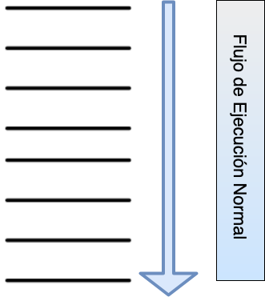

```python
from IPython.display import Image
Image(filename='./flujo_normal.png')
```

```python
x = 5     # Primero se crea una variable x y se le asigna el valor de 5.
print(x)  # Luego se llama a la función print para que imprima el valor de x
```

```
5
```

Debido a este orden no podemos hacer cosas como:

```python
print(valor_x) # Llama a la función print para que imprima el valor de valor_x
valor_x = 5    # Crear una variable valor_x y se le asigna el valor de 5
```

```
---------------------------------------------------------------------------
NameError                                 Traceback (most recent call last)
<ipython-input-447-1eecd0cececf> in <module>
----> 1 print(valor_x) # Llama a la función print para que imprima el valor de valor_x
      2 valor_x = 5    # Crear una variable valor_x y se le asigna el valor de 5

NameError: name 'valor_x' is not defined
```

Este error se genera debido a que `valor_x` no se ha creado cuando se ejecuta el `print` debido al flujo de la ejecución, pero existen maneras de alterar este flujo y una de esas maneras es mediante ciclos.

Los ciclos nos van a permitir repetir un código, es decir crear una repetición en el flujo de ejecución.

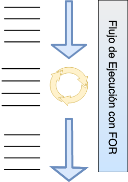

```python
from IPython.display import Image
Image(filename='./flujo_for.png')
```

En este caso la sentencia `for` nos ayuda a crear una repetición mientras nos movemos entre los elementos de una estructura iterable.

**for** < nombre de la variable que cambia > **in** < iterable > :

# ... Cualquier código que queramos repetir

# ... El código que está dentro del for (el que se repite) posee una tabulacion superior a la del for

# ... Este código no se repite

Las estructuras iterables son aquellas que nos permite recorrerlas fácilmente, en Python existen varias pero las más importantes son:

- `str`
- `list`
- `tuple`
- `range`
- `dict`

Por ejemplo si queremos imprimir cada uno de los caracteres del string "HOLA", podríamos hacer lo de la siguiente manera:

```python
saludo = "HOLA"
print(saludo[0])
print(saludo[1])
print(saludo[2])
print(saludo[3])
```

```
H
O
L
A
```

Pero utilizar esa forma es muy complicada y si tuviéramos un texto más grande ya no sería factible, por eso lo correcto sería usar un `for`.

```python
for letra in saludo:
    print(letra)
```

```
H
O
L
A
```

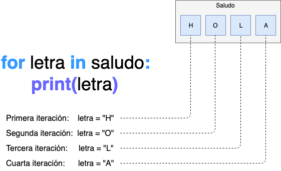

```python
from IPython.display import Image
Image(filename='./for.png')
```

Otro ejemplo podría ser calcular la sumatoria de una lista sin usar la función `sum`

```python
valores = [1, 20, 10, 7]
sumatoria = 0

for elemento in valores:
    sumatoria = sumatoria + elemento

print(sumatoria) # Este código está fuera del for así que no se repite.
```

```
38
```

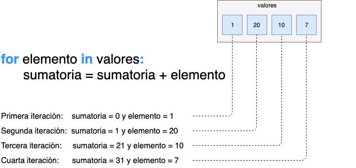

```python
from IPython.display import Image
Image(filename='./for2.png')
```

Veamos el mismo ejemplo de la sumatoria pero esta vez agregando `print` para ver los valores de `sumatoria` y de `elemento`

```python
valores = [1, 20, 10, 7]
sumatoria = 0

for elemento in valores:
    print("sumatoria: %i\nelemento: %i" % (sumatoria, elemento))
    sumatoria = sumatoria + elemento
    print("sumatoria = sumatoria + elemento\nsumatoria: %i\n" % (sumatoria) + "="*15 )

print(sumatoria)
```

```
sumatoria: 0
elemento: 1
sumatoria = sumatoria + elemento
sumatoria: 1
===============
sumatoria: 1
elemento: 20
sumatoria = sumatoria + elemento
sumatoria: 21
===============
sumatoria: 21
elemento: 10
sumatoria = sumatoria + elemento
sumatoria: 31
===============
sumatoria: 31
elemento: 7
sumatoria = sumatoria + elemento
sumatoria: 38
===============
38
```

No siempre nos conviene iterar en los elementos de una estructura iterable, en ocasiones nos sirve más iterar en los índices de estás estructura. Por ejemplo:

Si queremos imprimir la información de unos clientes, pero tenemos la información en dos listas distintas.

```python
edades = [23, 20, 24]
nombres = ["Juan", "Pedro", "Maria"]
```

Para este caso la estructura iterable que nos sirve usar es `range`.

```python
for indice in range(len(edades)):
    cadena = "Nombre: %s\nEdad:%i\n" % (nombres[indice], edades[indice])
    cadena = cadena + "=" * 15
    print(cadena)
```

```
Nombre: Juan
Edad:23
===============
Nombre: Pedro
Edad:20
===============
Nombre: Maria
Edad:24
===============
```

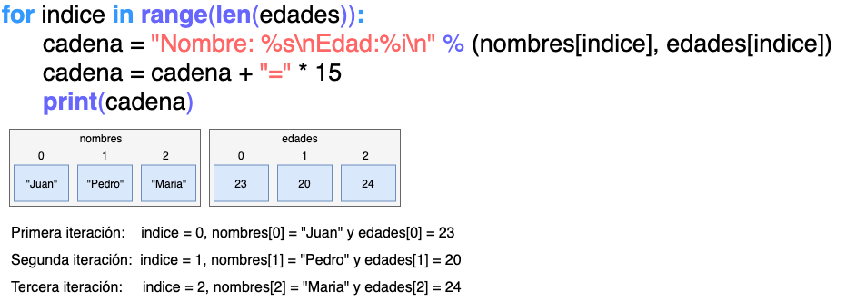

```python
from IPython.display import Image
Image(filename='./for3.png')
```

Un error muy común es tratar de obtener una lista numérica a la cual se le aplica una fórmula de la siguiente manera:

```python
x = list(range(1,11))
x = x ** 2
```

```
---------------------------------------------------------------------------
TypeError                                 Traceback (most recent call last)
<ipython-input-458-3a8bd36e6104> in <module>
      1 x = list(range(1,11))
----> 2 x = x ** 2

TypeError: unsupported operand type(s) for ** or pow(): 'list' and 'int'
```

Pero la forma correcta es usando un `for`

```python
lista_cuadrados = []

for valor in range(1,11):
    cuadrado = valor ** 2
    lista_cuadrados.append(cuadrado)

print(lista_cuadrados)
```

```
[1, 4, 9, 16, 25, 36, 49, 64, 81, 100]
```

Un error muy común, es olvidar agregar los tabs correspondientes del código dentro del `for`

```python
magos = ['alice', 'david', 'carolina']
for m in magos:
print(m)
```

```
  File "<ipython-input-460-c9e56e662aee>", line 3
    print(m)
        ^
IndentationError: expected an indented block
```

Pero la forma correcta es:

```python
magos = ['alice', 'david', 'carolina']
for m in magos:
    print(m)
```

```
alice
david
carolina
```

Al igual que con las lista y tuplas podemos recorrer un diccionario con un `for`

```python
cliente
```

```
{'nombre': 'Juan', 'edad': 55, 'telefonos': [22222222, 99999999], 'sexo': 'M'}
```

Si usamos directamente la variable `cliente` (un diccionario) como la estructura iterable en el `for` los que vamos a estar iterando son las llaves del diccionario:

```python
for llave in cliente:
    print(llave)
```

```
nombre
edad
telefonos
sexo
```

Por lo cual vamos a tener que usar `[]` para acceder a los valores

```python
for llave in cliente:
    cadena = "%s -> %s" % (llave, str(cliente[llave]))
    print(cadena)
```

```
nombre -> Juan
edad -> 55
telefonos -> [22222222, 99999999]
sexo -> M
```

Pero también podemos usar algunas funciones que nos ayudan a cambiar el recorrido del `for`

Podemos usar la función `values` para recorrer en los valores del diccionario.

```python
cliente.values()
```

```
dict_values(['Juan', 55, [22222222, 99999999], 'M'])
```

```python
for valor in cliente.values():
    print(valor)
```

```
Juan
55
[22222222, 99999999]
M
```

Podemos usar la función `items` para obtener las llaves y los valores en tuplas.

```python
cliente.items()
```

```
dict_items([('nombre', 'Juan'), ('edad', 55), ('telefonos', [22222222, 99999999]), ('sexo', 'M')])
```

```python
for llave, valor in cliente.items():
    cadena = "%s -> %s" % (llave, valor)
    print(cadena)
```

```
nombre -> Juan
edad -> 55
telefonos -> [22222222, 99999999]
sexo -> M
```